# FlickrIntro

Yi Lin Liu

April 4, 2017

## Basics of Flickr:

- [Guide to use Flickr](https://www.cnet.com/news/newbies-guide-to-flickr/)
- [Guide to API](http://kylerush.net/blog/flickr-api/)

## Learning API:

- [Flickr API](https://www.flickr.com/services/api/)
  - **NOTE: not supported by Flickr, so might not be stable.**
  - All uses of the API must abide the [community guidelines](https://www.flickr.com/help/guidelines/)
- Results can be cached for up to 24 hours to reduce API load.
- Flickr has its own shortened URL. [Shortened URL](https://www.flickr.com/groups/api/discuss/72157616713786392)
- To perform requests, a calling convention is needed, send a request to its endpoint specifying the requried parameters (method,api_key) and other arguments, a formatted response will be recieved.
  - Endpoint: `https://api.flickr.com/services`
- All requests/data are expected to be UTF-8 enconded.
- Oauth is used for authentication.

## Rate Limit:

- Staying under aggregate 3600 requests per hour per key will be allowed.

## Obtaining Authorization:

- [API Key](https://www.flickr.com/services/apps/create/)
  - click on *Request an API Key* under “Get your API Key”
  - select non-commercial.
  - An call back URL must be specified.
- [Generating Key](https://www.flickr.com/services/api/auth.oauth.html)
  - all the listed URLs are available on this website.
- The token does not seem to have an expiration date.
- **FOR THE FOLLOWING TO WORK, when R opens the popup, change `permission=read` to `perms=read` in the URL. The permissions must be specified or the authentication page will show `permission set not recognized` error.**

[figure not shown]

  Correct Auth Page

```r
    rm(list = ls())

    library(httr)

    # ##  Retrieved from API Documentation + Generated Key
    # app_Key <- "08adb0273ae63e5c07c249f5a621e7cb"
    # app_Secret <- "89e0a70bfb48e7f4"
    # request_URL <- "https://www.flickr.com/services/oauth/request_token"
    # auth_URL <- "https://www.flickr.com/services/oauth/authorize"
    # access_URL <-"https://www.flickr.com/services/oauth/access_token"
    #
    # token.endpoints <- oauth_endpoint(request= request_URL, authorize = auth_URL,
    #                                   access = access_URL)
    # token.app <- oauth_app("Testing API",key=app_Key, secret = app_Secret )
    # token <- oauth1.0_token(token.endpoints, token.app,permission='read',cache=F)
    #
    #
    # ##  Saving Token:
    # saveRDS(token,file="token.R")
```

## API Methods of Interest:

- [flickr.contacts.getListRecentlyUploaded](https://www.flickr.com/services/api/flickr.contacts.getListRecentlyUploaded.html): retrieves a list of contacts(friends) for a user who have recently posted as well as number of photos.
- [flickr.photos.search](https://www.flickr.com/services/api/flickr.photos.search.html): The public search method that returns a list of photos matching the tags specified.
- [flickr.photos.getExif](https://www.flickr.com/services/api/flickr.photos.getExif.html): This method returns the EXIT/TIFF/GPS tags associated with the photo.
- More photo methods:
  - [popular photos](https://www.flickr.com/services/api/flickr.photos.getPopular.html)
  - [recent photos](https://www.flickr.com/services/api/flickr.photos.getRecent.html)
  - [contact public photos](https://www.flickr.com/services/api/flickr.photos.getContactsPublicPhotos.html)
  - [comments to a photo](https://www.flickr.com/services/api/flickr.photos.comments.getList.html)
  - [location for photos](https://www.flickr.com/services/api/flickr.photos.geo.getLocation.html)
- The listed methods mainly focuses on dealing with photos. For methods that allows the exploration of friendship (contacts), finiding users, please refer to the [Flickr API Documentation](https://www.flickr.com/services/api/)

## Test Account:

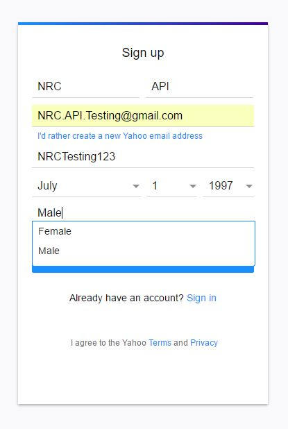

Registration

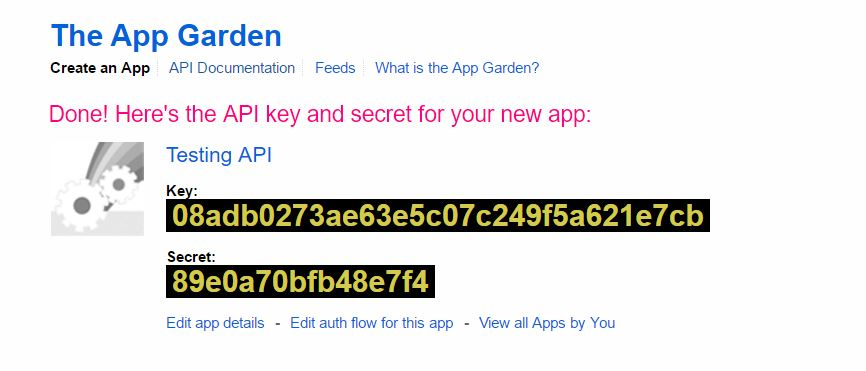

App Key and Secret